# Sztuczne Sieci Neuronowe

Karol Szpyt, Katarzyna Rzeszutek, Agnieszka Szymczyk

16 listopada 2018

## Wstęp

Opis problemu: Tematem projektu jest budowa sztucznej sieci neuronowej. W naszym projekcie przeprowadzimy również badania dotyczące jej działania. Pierwszą czynnością będzie wybór danych. W naszym przypadku jest to zbiór obserwacji dotyczący trzech rodzajów ziaren pszenicy.

Ładujemy potrzebne biblioteki

```r
library(neuralnet)
library(nnet)
library(rpart)
library(rattle)
library(rpart.plot)
library(RColorBrewer)
```

## Opis danych

Nasze dane opierają się na pomiarach właściwości geometrycznych nasion (ziaren) należących do trzech różnych odmian pszenicy. Do skonstruowania wszystkich siedmiu atrybutów o rzeczywistych wartościach zostały wykorzystana technika rentgenowska.

Badaną grupę stanowiły ziarna należące do trzech różnych odmian pszenicy: **Kama**, **Rosa** i **Canadian**, każda po 70 elementów, losowo wybranych do eksperymentu. Wysokiej jakości wizualizacja wewnętrznej struktury nasiona została wykryta za pomocą techniki rentgenowskiej. Jest ona nieniszcząca (dla nasion) i znacznie tańsza niż inne, bardziej wyrafinowane techniki obrazowania, takie jak np. technologia laserowa. Obrazy rejestrowano na płytach rentgenowskich KODAK o wymiarach: 13x18 cm. Badania przeprowadzono przy użyciu ziaren pszenicy zebranych z pól doświadczalnych, zbadanych w Instytucie Agrofizyki Polskiej Akademii Nauk w Lublinie.Zestaw danych można wykorzystać do zadań klasyfikacji i analizy skupień(grupowania).

Aby skonstruować dane, zmierzono siedem parametrów geometrycznych ziarna pszenicy. Atrybuty:

1. Obszar A,
2. Obwód B,
3. Zwartość C = 4 * pi * A / P ^ 2,
4. Długość ziarna,
5. Szerokość ziarna,
6. Współczynnik asymetrii,
7. Długość rowka ziarna.
8. Zmienna label mówiąca o typie pszenicy (1, 2, 3) Wszystkie z powyższych parametrów były wartościowane w sposób ciągły.

Następnie wczytujemy dane, na których będziemy pracować

```r
data <- read.table("seeds.txt", sep = "\t")
names(data) <- c("area_A",
                 "perimeter_P",
                 "compactness_C",
                 "length_of_kernel",
                 "width_of_kernel",
                 "asymmetry_coefficient",
                 "length_of_kernel_groove",
                 "label"
)
```

Szybkie spojrzenie na dane na poglądowych wykresach

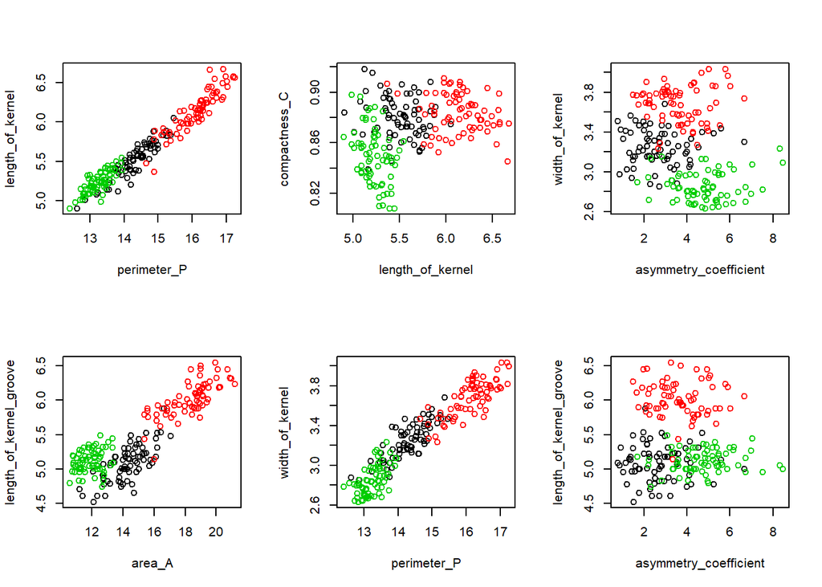

```r
par(mfrow = c(2, 3))
plot(length_of_kernel ~ perimeter_P, col = label)
plot(compactness_C ~ length_of_kernel, col = label)
plot(width_of_kernel ~ asymmetry_coefficient, col = label)
plot(length_of_kernel_groove ~ area_A, col = label)
plot(width_of_kernel ~ perimeter_P, col = label)
plot(length_of_kernel_groove ~ asymmetry_coefficient, col = label)
```

Ewidentnie widać podział na grupy. Sieć powinna mieć wysoką skuteczność.

## Przygotowanie danych

Rozdzielamy zmienną “label” na 3 zmienne binarne i standaryzujemy dane, aby były wartościami od 0 do 1.

```r
#Rozdzielanie zmiennej "label"
data2 <- cbind(data[, 1:7], class.ind(as.factor(data$label)))
names(data2) <- c(names(data)[1:7],"K", "R", "C")

#Standaryzacja danych, aby były wartościami od 0 do 1
maximum<-apply(data2[,1:7], 2, max)
minimum<-apply(data2[,1:7], 2, min)
data3 <- as.data.frame(scale(data2[, 1:7], center = minimum,scale=maximum-minimum))
data2 <- cbind(data3, data2[,8:10])
```

Następnie dbamy o wymieszanie naszych danych.

```r
#Powodujemy wymieszanie danych
data2 <- data2[sample(1:210, 210),]
```

Kolejnym krokiem jest utworzenie formuły do wykorzystanie funkcji *neuralnet*.

```r
#tworzymy formułę
n <- names(data2)
f <- as.formula(paste("K + R + C ~", paste(n[!n %in% c("K", "R", "C")], collapse = " + ")))
f
```

```
## K + R + C ~ area_A + perimeter_P + compactness_C + length_of_kernel +
##     width_of_kernel + asymmetry_coefficient + length_of_kernel_groove
```

```r
foo <- function(x = c(3, 4), fct = "logistic", n = 6)
{
  set.seed(500)
  #walidacja krzyżowa
  for(i in 1:n)
  {
    index <- (((i-1) * round((1/n)*nrow(data2))) + 1):((i*round((1/n) * nrow(data2))))
    train_cv <- data2[index, ]
    test_cv <- data2[-index, ]
    nn_cv <- neuralnet(f,
                       data = train_cv,
                       hidden = x,
                       act.fct = fct,
                       linear.output = FALSE)


    pr.nn <- compute(nn_cv, test_cv[, 1:7])
    pr.nn_ <- pr.nn$net.result

    original_values <- max.col(test_cv[, 8:10])
    pr.nn_2 <- max.col(pr.nn_)
    outs[i] <- mean(pr.nn_2 == original_values)
  }
  a <- mean(outs)
  return(a)
}
```

Sprawdźmy skuteczność naszej sieci przy domyślnych parametrach

```
## [1] 0.8942857143
```

funkcja obliczająca skutecznosć sieci w zależności od konfiguracji neuronów. Argument **y** jest tym samym argumentem co argument **x** w funckji **foo**, jednakże funckja **config** zwraca wektor skuteczności dla kolejnych kombinacji neuronóW.

```r
config <- function(y)
{
  a <- NULL
  for (x in 1:dim(y)[1]) {
    a[x] <- foo(y[x,])
  }
  return(a)
}
```

Sprawdzamy skuteczność sieci z jedną warstwą ukrytą. Liczba neuronóW zmienia się od 1 do 100.

```r
k <- NULL
for (x in 1:100) {
  k[x] <- foo(x)
}
a <- NULL
a <- c(which(k == max(k)), max(k))
names(a) <- c("liczba neuronów", "skuteczność")
a
```

```
## liczba neuronów     skuteczność
##   84.0000000000    0.9228571429
```

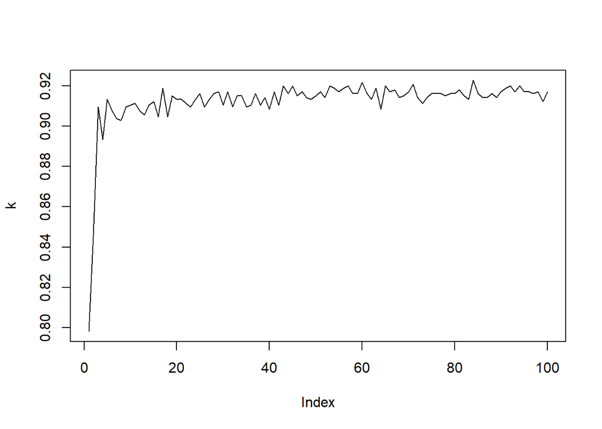

```r
plot(k, type = "l")
```

Sprawdzamy teraz zachowanie sieci przy zmianie liczby neuronów na dwóch warstwach. Z uwagi na bardzo dużą ilość kombinacji (w szczególości w następnych warstwach) liczba neuronóW na każdej z warst wahać się będzie pomiędzy 1 a 25. Ponadto wybrane zostanie losowo 10 kombinacji i na tych 10 kombinacjach sprawdzona zostanie skuteczność sieci

```r
set.seed(500)
kk <- expand.grid(1:25, 1:25)
ii <- sample(1:dim(kk)[1], 10)
kk <- kk[ii,]
kk <- cbind(kk, config(kk))
rownames(kk) <- 1:10
names(kk) <- c("1st", "2nd", "skuteczność")
w2 <- kk
w2
```

```
##    1st 2nd  skuteczność
## 1   21  21 0.8971428571
## 2    3  19 0.8980952381
## 3    8  25 0.9104761905
## 4   16  12 0.8952380952
## 5    5  21 0.9000000000
## 6    3   6 0.8895238095
## 7   18  13 0.8971428571
## 8   22  23 0.9028571429
## 9   12  21 0.8990476190
## 10  14  18 0.8990476190
```

Ta sama sytuacja co powyżej aczkolwiek dla trzech warst

```r
set.seed(500)
kk <- expand.grid(1:25, 1:25, 1:25)
ii <- sample(1:dim(kk)[1], 10)
kk <- kk[ii,]
kk <- cbind(kk, config(kk))
rownames(kk) <- 1:10
names(kk) <- c("1st", "2nd", "3nd", "skuteczność")
w3 <- kk
w3
```

```
##    1st 2nd 3nd  skuteczność
## 1   25  21  21 0.8923809524
## 2    3   4  19 0.8857142857
## 3   13  10  25 0.8971428571
## 4    5  18  12 0.8885714286
## 5   14   8  21 0.8933333333
## 6   13   4   6 0.8990476190
## 7   25  20  13 0.8933333333
## 8    4   4  24 0.8847619048
## 9   19  18  21 0.8771428571
## 10  12  20  18 0.9000000000
```

Dla czterech

```r
set.seed(500)
kk <- expand.grid(1:25, 1:25, 1:25, 1:25)
ii <- sample(1:dim(kk)[1], 10)
kk <- kk[ii,]
kk <- cbind(kk, config(kk))
rownames(kk) <- 1:10
names(kk) <- c("1st", "2nd", "3nd", "4th", "skuteczność")
w4 <- kk
w4
```

```
##    1st 2nd 3nd 4th  skuteczność
## 1   25  25  21  21 0.8866666667
## 2    8   4   4  19 0.8857142857
## 3    6  15  10  25 0.8819047619
## 4    7   7  18  12 0.8914285714
## 5   18  17   8  21 0.8952380952
## 6   24  14   4   6 0.8980952381
## 7   18   3  21  13 0.9000000000
## 8    4  11   4  24 0.8914285714
## 9    6   1  19  21 0.8523809524
## 10   4  19  20  18 0.8666666667
```

Oraz pięciu

```r
set.seed(500)
kk <- expand.grid(1:25, 1:25, 1:25, 1:25, 1:25)
ii <- sample(1:dim(kk)[1], 10)
kk <- kk[ii,]
kk <- cbind(kk, config(kk))
rownames(kk) <- 1:10
names(kk) <- c("1st", "2nd", "3nd", "4th", "5th", "skuteczność")
w5 <- kk
w5
```

```
##    1st 2nd 3nd 4th 5th  skuteczność
## 1   25  25  25  21  21 0.8961904762
## 2   18   8   4   4  19 0.8914285714
## 3    1   8  15  10  25 0.8019047619
## 4   18   8   7  18  12 0.8838095238
## 5    1  22  17   8  21 0.8028571429
## 6   23  25  14   4   6 0.8914285714
## 7   24  21   3  21  13 0.8904761905
## 8   23  10  11   4  24 0.8904761905
## 9    1  13   1  19  21 0.7257142857
## 10  14  10  19  20  18 0.8838095238
```

## Drzewo decyzyjne

Poniżej wyświetlone jest drzewo decyzyjne.

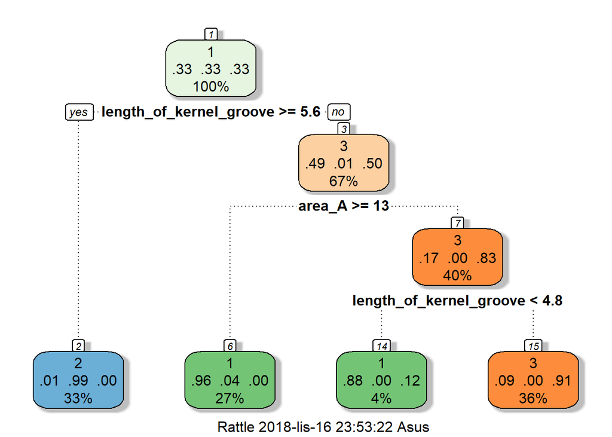

```r
tree <- rpart(label ~ ., data, method = "class")
fancyRpartPlot(tree)
```